# Youtube video data

## Videos viewed by category

Okay, to start things off, my visual data story is going to be about YouTube video viewing and how it is affected by different factors. Let’s begin by talking about how the category of the video affected the viewership per entry into our data set and, sequentially, into our graph. From the graph, it is mostly reflected that entertainment and gaming were the most viewed categories of videos. Personally, this reflection makes sense, as the data was logged through what I had mostly seen on YouTube. I tend to lean towards these categories more because gaming is one of my biggest hobbies, while entertainment mainly consisted of movies and anime, which are also some of my favourite interests. Because of this, it makes sense that most of the observations tended to favour these two categories the most.

I chose a bar graph because it is visually the clearest way to display the count of observations across the different categories. The blue colour palette was chosen to make the bars visually stand out and grab the viewer’s attention. Additionally, the cool undertone of the light blue is visually appealing and fits the overall aesthetic of the report.

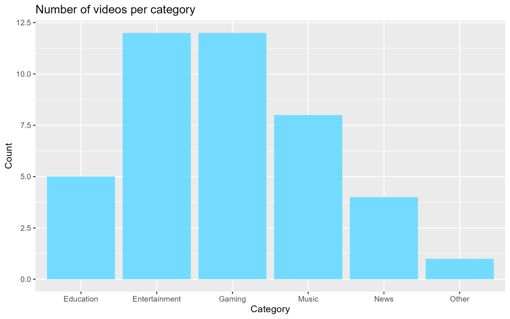

Number of videos per category - graph

## Average(Mean) duration relation to category

Now let’s talk about the average (mean) duration by category and the relationship between these two variables. When extracting the data for this graph, I had to create a separate data set that recorded the average video duration grouped together by category. The data was then summarised to calculate the mean or average duration per category.

As hinted at previously, I decided to use a column graph instead of a bar graph because the data had already been summarised beforehand. This makes the visualisation more accurate for representing average values. Continuing with the blue theme, I decided to choose a darker shade this time. Firstly, this helps distinguish the graph from the previous one, and secondly, it gives the graph a stronger sense of order and structure. The darker tone helps bring more attention and focus to the visualisation.

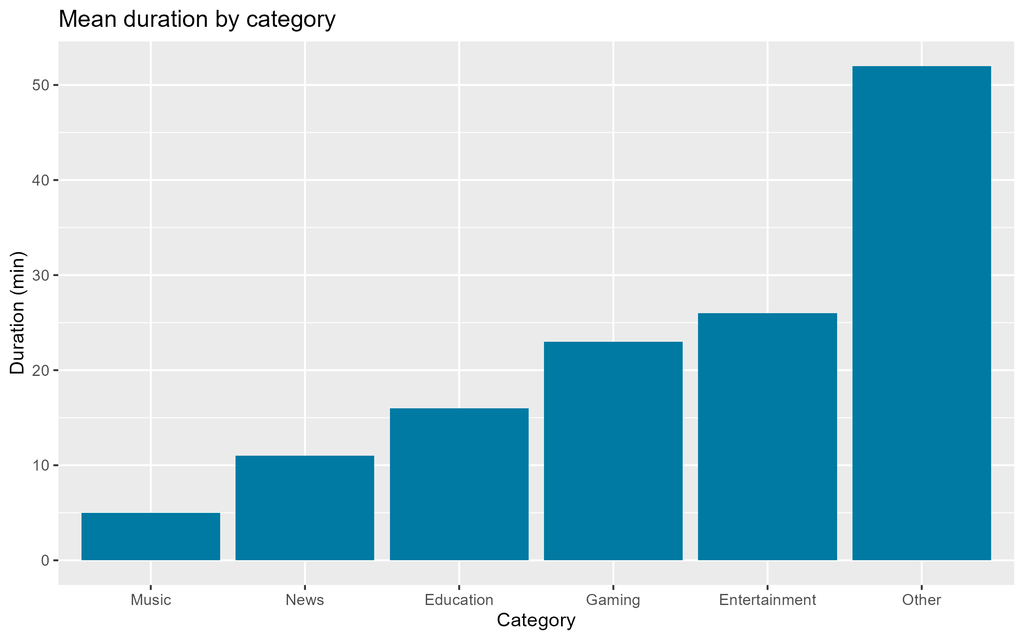

## Video viewership affected by date

Continuing on, let’s talk about how the date on which the observations were made influenced the number of videos viewed. This data was acquired by using the {lubridate} library and manipulating the initial data set to obtain dttm objects. These objects were then inserted into a new data set in order to extract the date variable. Next, the data set containing the date variable was grouped by date, and the total number of videos viewed per date was summarised. The graph below reflects this processed data.

From the graph, we can see that there were two dates that were significant in viewership, and both were roughly similar in value. Overall, this suggests that there was not a particularly strong relationship between the specific date and the number of videos viewed. The colour scheme still follows the overall blue theme, but this time I shifted slightly towards a lavender-like colour. This was done to help distinguish the graph from the previous visualisations while still maintaining the softer colour palette used throughout the report. The lighter tone also reflects that this graph is not intended to carry as much analytical focus as some of the previous visualisations.

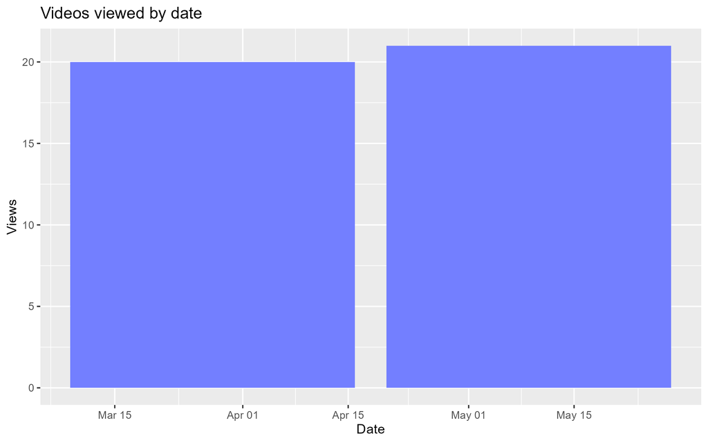

## Video duration and completion

Lastly, let’s talk about the relationship between the duration of a video and how likely I was to finish watching it. For this particular data set, I added a new variable into my Google Sheet which recorded whether I had finished watching the video related to each observation. I added this variable because I wanted to investigate whether the likelihood of finishing a video was affected by its duration, and whether longer videos had a higher chance of not being completed.

As you can see, this plot is visually quite distinct from the previous graphs. I chose to use a jitter plot in order to display the individual data points from my observations more clearly. This makes it easier to immediately identify which category tended to favour particular duration values.

From the graph, we can see that there were more observations indicating that the video was watched until the end compared to those that were not completed. Because of this imbalance, I would argue that the data collection is not entirely unbiased between the two categories of “Yes” and “No.” As a result, there may appear to be a stronger relationship between lower video duration and higher completion rates compared to higher duration and lower completion rates.

Due to the somewhat uneven nature of the data, I cannot confidently conclude that video completion is directly correlated to video length. However, the graph does seem to suggest that shorter videos were generally more likely to be completed. The colour scheme was intentionally chosen to differ from the previous graphs and breaks away slightly from the dominant blue motif. This was done to better distinguish the comparison being presented and to help the viewer focus more clearly on the relationship shown in the data.

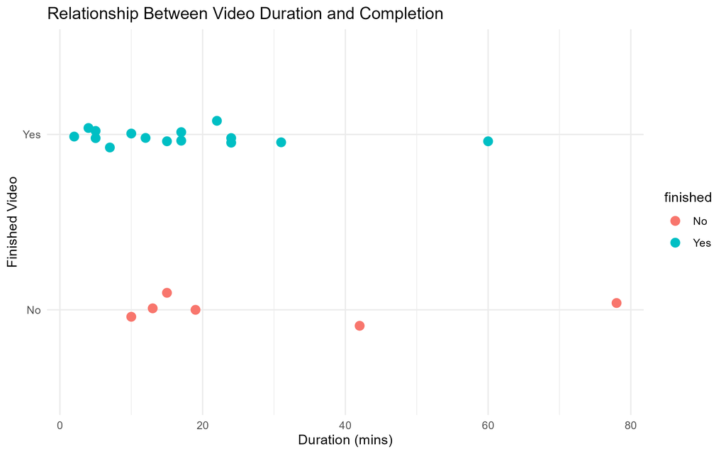

Relationship between Video duration and completion